# Homework 12

Alison Hall

4/27/2020

1. For this exerise, use your newly-developed ggplot chops to create some nice graphs from your own data (If you do not have a good data frame to use for graphics, use one of the many built-in data frames from R (other than mpg, which we are using in class)). Experiment with different themes, theme base sizes, aesthetics, mappings, and faceting. When you are finished, try exporting them to high quality pdfs, jpgs, eps files, or other formats that you would use for submission to a journal. In this exercise, I encourage you to improve your graphics with elements that we have not (yet) covered in ggplot. For example, can you change the labels on a facet plot so that they are more informative than the variable names that are supplied from your data frame? Can you figure out how to add text annotations, lines and arrows to your graph? Can you figure out how to use custom colors that you have chosen for your fills and lines? Your resources for these explorations are google, Stack Overflow – and Lauren!

Step one: load libraries and data set. Data set used here lists different treatment types- steady and gradual and how long it took an urchin to right itself. There were 4 individuals in the steady group (Steady3,Steady4, Steady7, Steady8) and 3 individuals in the gradual treatment group (Gradual1, Gradual2, Gradual6).

Make plots! here’s a boxplot

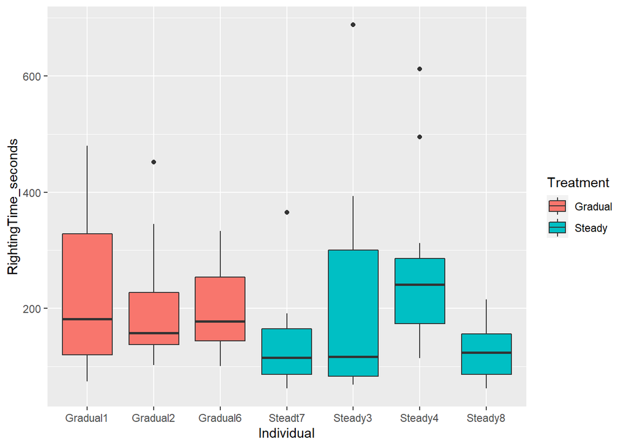

```r
BoxPlot <- ggplot(data=SalinityData3, aes(x=Individual, y=RightingTime_seconds)) + geom_boxplot(aes(fill=Treatment))
print(BoxPlot)
```

This version of the box plots shows the distribution of a righting times doe an individual urchin across the duration of the experiment. Each dot is righting time on a different day of the study.

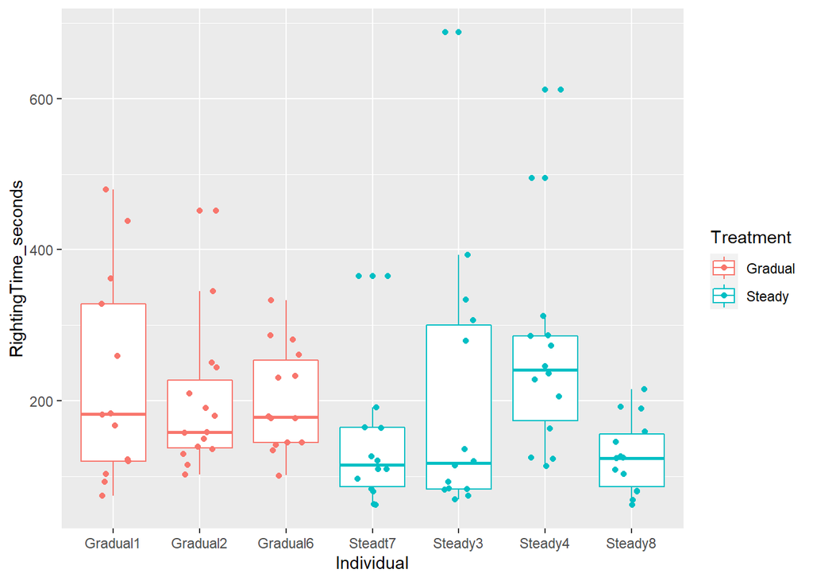

```r
jitterboxplot <- ggplot(data=SalinityData3, aes(x=Individual, y=RightingTime_seconds, color=Treatment)) +
  geom_boxplot() + geom_jitter(position = position_jitter(0.2))
print(jitterboxplot)
```

Violin plots with box plots allow us to see the density of righting time data as well. I like this one, so I saved it to a pdf!

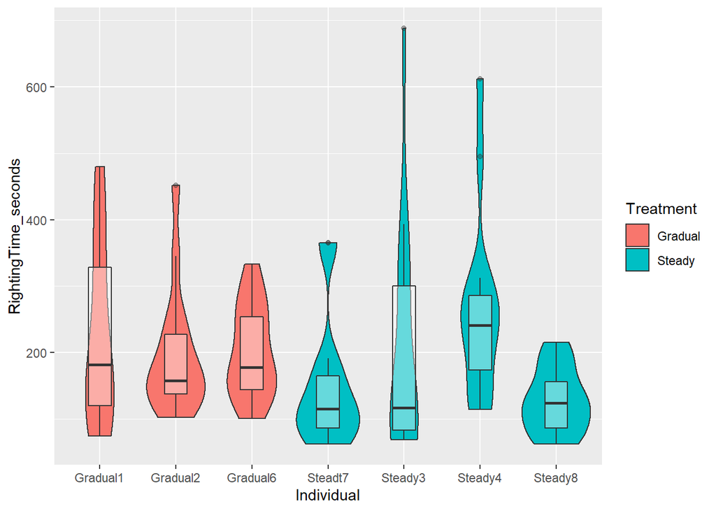

```r
violinbox <- ggplot(SalinityData3) + geom_violin(
  aes(x=Individual, y=RightingTime_seconds,
    fill=Treatment)) + geom_boxplot(aes(x=Individual,
                                        y=RightingTime_seconds),
                                        width=0.3,
                                        alpha=0.4)
print(violinbox)
```

```r
ggsave("violinbox.pdf") #saving this last one to a pdf :)
```